# STATS369 A4

Lin Lin

2023-10-16

# Task 1

### (a) & (b)

```r
# Set seed
set.seed(829)

# Load data
bank.df <- read.csv('bank_marketing.csv', sep = ";")
head(bank.df)
```

```
##   age       job marital   education default housing loan   contact month
## 1  56 housemaid married    basic.4y      no      no   no telephone   may
## 2  57  services married high.school unknown      no   no telephone   may
## 3  37  services married high.school      no     yes   no telephone   may
## 4  40    admin. married    basic.6y      no      no   no telephone   may
## 5  56  services married high.school      no      no  yes telephone   may
## 6  45  services married    basic.9y unknown      no   no telephone   may
##   day_of_week duration campaign pdays previous    poutcome emp_var_rate
## 1         mon      261        1   999        0 nonexistent          1.1
## 2         mon      149        1   999        0 nonexistent          1.1
## 3         mon      226        1   999        0 nonexistent          1.1
## 4         mon      151        1   999        0 nonexistent          1.1
## 5         mon      307        1   999        0 nonexistent          1.1
## 6         mon      198        1   999        0 nonexistent          1.1
##   cons_price_idx cons_conf_idx euribor3m nr_employed  y
## 1         93.994         -36.4     4.857        5191 no
## 2         93.994         -36.4     4.857        5191 no
## 3         93.994         -36.4     4.857        5191 no
## 4         93.994         -36.4     4.857        5191 no
## 5         93.994         -36.4     4.857        5191 no
## 6         93.994         -36.4     4.857        5191 no
```

```r
sum(is.na(bank.df))
```

```
## [1] 0
```

### (c)

1. The ‘duration’ variable should be discarded as it not known before the call is performed and y is known after call. It is not conducive to a model whose main focus is prediction. Hence, this input should be discarded if the intention is to have a realistic predictive model.
2. ‘Day of week’ should be removed as the day of week seems not play a significant role whether client subscribe or not. Similarly, month can be removed as well.
3. ‘Contact’ could also be removed as it doesn’t affect the outcome.
4. ‘pdays’ is number of days that passed by after the client was last contacted from a previous campaign, this factor might not be significant for prediction as most of values are 999.
5. ‘poutcome’ is the outcome of the previous marketing campaign, most of value is ‘nonexistent’ indicate that the result of previous campaign might not affect prediction a lot.
6. The index variables could be removed as they are not meaningful.

# Task 2

### (a)

```r
set.seed(829)

# Discard variables
banknew.df <- bank.df %>%
  select(-c(contact, month, day_of_week, duration, pdays, poutcome, cons_price_idx, cons_conf_idx))

# Recode 'y' as 0 and 1
banknew.df$y <- ifelse(banknew.df$y == "no", 0, 1)
banknew.df$y <- as.factor(banknew.df$y)

# Split the data into 90% training and 10% test sets
idx <- sample(1:nrow(banknew.df), 0.9 * nrow(banknew.df))
train.df <- banknew.df[idx,]
test.df <- banknew.df[-idx,]
```

### (b) & (c)

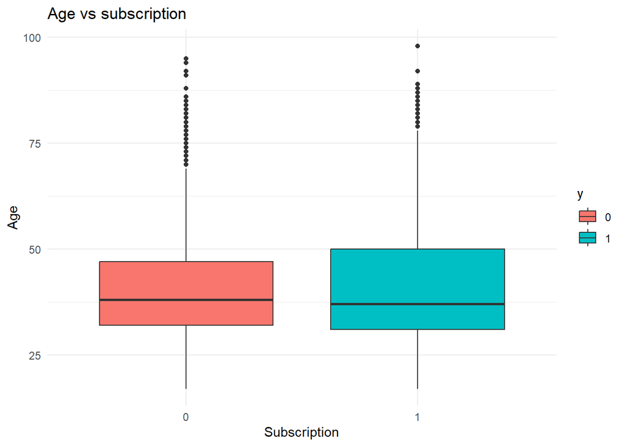

```r
# Create a box plot that show the relationship between age and subscription
banknew.df %>%
  ggplot() +
  geom_boxplot(aes(x = y,
             y = age,
             fill = y)) +
  labs(title = 'Age vs subscription',
       x ='Subscription',
       y = 'Age') +
  theme_minimal()
```

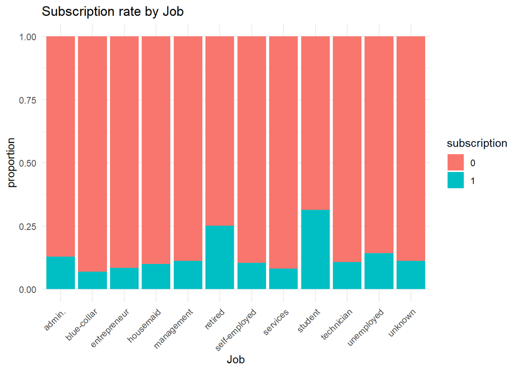

```r
# Create bar plot show the proportion of subscription for each type of job
banknew.df %>%
  ggplot() +
  geom_bar(aes(x = job,
             fill = y), position = 'fill') +
  labs(title = 'Subscription rate by Job',
       x = 'Job',
       y = 'proportion',
       fill = 'subscription') +
  theme_minimal() +
  theme(axis.text.x = element_text(angle = 45, hjust = 1)) # Rotate the text at a 45 degree angle and easy for reading
```

The bar plot shows the proportion of ‘yes’ and ‘no’ subscriptions for each job category. Different colors distinguish subscribers from non-subscribers. The retired group and student group has the most of proportion of subscriptions which seems reasonable, since retired people need savings for their later life and students usually have deposit for their future study cost.

### (d)

1. Job might be important. Job type relate to client’s income level and stability. Higher salaries making them more likely to invest in financial products such as stock or term deposit. On the contrary, people with less income are less likely to have term deposit. Therefore, job type is a key attribute that affects whether a client subscribes.
2. Age is another variable that may important in predicting. For example, middle-aged clients might have more savings and higher risk awareness that securing their future compared to younger clients. Also, older clients at retire stage, specifically over 65 years old tend to have more savings to secure their later life and cover medical costs etc.
3. Education can play an important role in predicting subscription. People with higher education levels might have higher incomes and a better understanding of financial knowledge leading them to subscribe term deposit and get certain return annually. On the other hand, the level of education is not absolute, there are low-level educators will also have regular term deposit, but the level of education can reflect the trend of subscription to a certain extent.

# Task 3

### (a)

```r
set.seed(829)


# Create logistic regression model
logistic_model <- glm(y ~ ., family = 'binomial', data = train.df)




# Create ridge regression model
x.train <- model.matrix(y ~ ., train.df)[, -1] # create training matrix for x
y.train <- as.numeric(train.df$y) - 1 # Numeric to have 0 and 1 as response categories
x.test <- model.matrix(y~., data = test.df)[,-1] # Create test matrix for x
lambdas <- 2^ seq(6, -4, length = 100) # lambda values

# cross validate with glmnet
ridge.cv <- cv.glmnet(x.train, y.train, family = 'binomial', alpha = 0, lambda = lambdas)

# Get best lambda from cross validation model
best_lambda <- ridge.cv$lambda.1se
ridge_model <- glmnet(x.train, y.train, alpha = 0, family = "binomial", lambda = best_lambda)




# Create Random Forest
forest_model <- ranger(y~., data = train.df, importance = 'impurity')





# Create XGboost model
xgb_train <- xgb.DMatrix(data = x.train, label = y.train) # Transform training data into Dmatrix format
xgb_test <- xgb.DMatrix(data = x.test) # Transform test data into Dmatrix format

#Create list of hyper-parameters
params <- list(objective = "binary:logistic",
               eval_metric = "logloss",
               eta = 1,
               max_depth = 3,
               nthread = 2
               )
# Implement cross validation function
xgb_cv <- xgb.cv(params = params,
                 data = xgb_train,
                 nrounds = 50,
                 nfold = 5,
                 early_stopping_rounds = 10,
                 verbose = 0)

xgboost_model <- xgboost(params = params, data = xgb_train, nrounds = xgb_cv$best_iteration)
```

### (b)

```r
set.seed(829)

# Make prediction for logistic model on test data
logistic_preds <- predict(logistic_model, test.df, type = 'response')
# Convert result of predictions to binary values 0 and 1
logistic_preds_convert <- ifelse(logistic_preds > 0.5, 1, 0)
# Create logistic confusion matrix
logistic_conf_matrix <- table(actual = test.df$y, predicted = logistic_preds_convert)
logistic_conf_matrix
```

```
##       predicted
## actual    0    1
##      0 3609   47
##      1  400   61
```

```r
# Make prediction for ridge regression model on test data
ridge_preds <- predict(ridge_model, s = best_lambda, x.test, type = 'response')
# Convert result of predictions to binary values 0 and 1
ridge_preds_convert <- ifelse(ridge_preds > 0.5, 1, 0)
# Create ridge confusion matrix
ridge_conf_matrix <- table(actual = test.df$y, predicted = ridge_preds_convert)
ridge_conf_matrix
```

```
##       predicted
## actual    0    1
##      0 3654    2
##      1  454    7
```

```r
# Make prediction for random forest model on test data
forest_preds <- predict(forest_model, test.df)
# Create random forest confusion matrix
forest_conf_matrix <- table(actual = test.df$y, predicted = forest_preds$predictions)
forest_conf_matrix
```

```
##       predicted
## actual    0    1
##      0 3567   89
##      1  334  127
```

```r
# Make prediction for xgboost model on test data
xgb_preds <- predict(xgboost_model, xgb_test)
# Convert result of predictions to binary values 0 and 1
xgb_preds_convert <- ifelse(xgb_preds > 0.5, 1, 0)
# Create xgboost confusion matrix
xgboost_conf_matrix <- table(actual = test.df$y, predicted = xgb_preds_convert)
xgboost_conf_matrix
```

```
##       predicted
## actual    0    1
##      0 3551  105
##      1  313  148
```

# Task 4

### (a)

```r
# Extract variable importance from random forest
ran_imp <- importance(forest_model)
ran_imp[1:6]
```

```
##       age       job   marital education   default   housing
## 974.87076 443.95844 204.71471 383.98938  69.09852 184.07779
```

```r
# Extract variable importance from xgboost
xgb_imp <- xgb.importance(feature_names = colnames(x.train), model = xgboost_model)
xgb_imp$Feature[1:6]
```

```
## [1] "nr_employed"  "euribor3m"    "emp_var_rate" "age"          "previous"
## [6] "campaign"
```

From result we can see that ‘age’ is one of common variables that appeared in both models. Hence, I will produce a plot showing how age related to y.

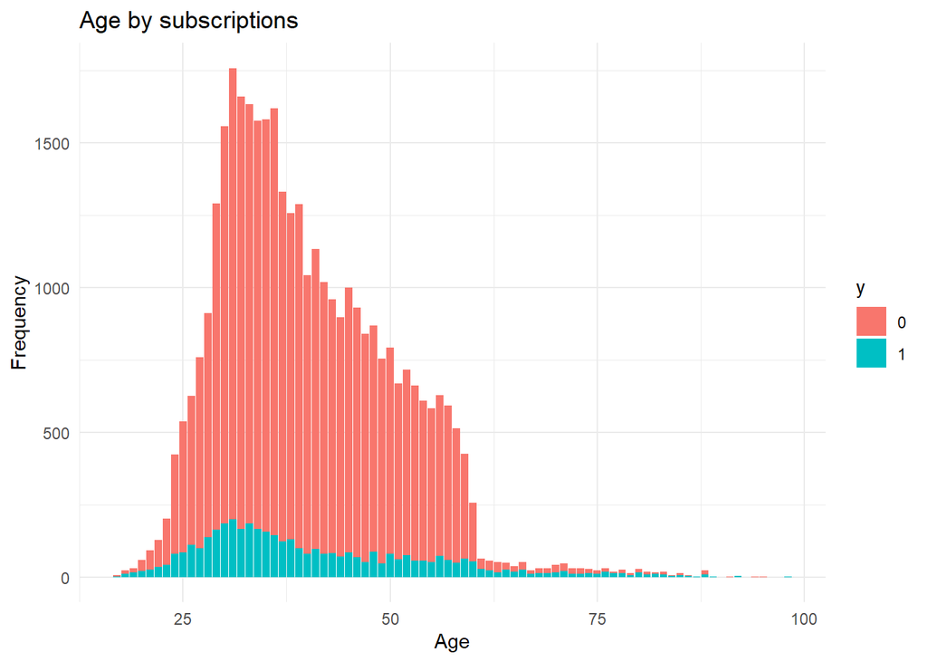

```r
ggplot(train.df, aes(x = age, fill = y)) +
  geom_bar() +
  labs(title = "Age by subscriptions",
       x = "Age",
       y = 'Frequency') +
  theme_minimal()
```

### (b)

```r
# Calculate misclassification rate for each model

# Misclassification rate of logistic model
logistic_mis <- (logistic_conf_matrix[1, 2]+logistic_conf_matrix[2, 1])/sum(logistic_conf_matrix)
logistic_mis
```

```
## [1] 0.1085742
```

```r
# Misclassification rate of ridge model
ridge_mis <- (ridge_conf_matrix[1, 2]+ridge_conf_matrix[2, 1])/sum(ridge_conf_matrix)
ridge_mis
```

```
## [1] 0.1107603
```

```r
# Misclassification rate of random forest model
forest_mis <- (forest_conf_matrix[1, 2]+forest_conf_matrix[2, 1])/sum(forest_conf_matrix)
forest_mis
```

```
## [1] 0.1027447
```

```r
# Misclassification rate of xgboost model
xgb_mis <- (xgboost_conf_matrix[1, 2]+xgboost_conf_matrix[2, 1])/sum(xgboost_conf_matrix)
xgb_mis
```

```
## [1] 0.1015302
```

From above results we can see that xgboost has the lowest misclassification rate, however, the difference in performance among the models is relatively small.

### (c)

**Executive Summary:**

In order to improve our bank’s marketing strategies, we’ve undertaken a comprehensive analysis of data from previous marketing campaigns. Our primary objective is to understand the factors influencing a customer’s decision to subscribe to a term deposit, allowing us to predict future customer behavior and adjust our marketing strategy accordingly.

We also found that specific group of individuals, such as students and retired people, showed a higher probability towards subscribing. Moreover, age is also a key factor that revealing specific age groups showing a higher likelihood to subscribe. These perspectives can help us quickly target the market and segment the potential audience. We can develop a more approach to achieve further proactive marketing strategies, for example, understanding features like the number of times a client was contacted would significantly influence their decision. We can optimize our engagement frequency, ensure that we don’t under or over-contact customers and personalize our approach based on individual profiles.

Overall, by analyzing data set, we’re not just reacting to market trends, but proactively enhancing our strategies to meet customer needs, driving both customer satisfaction and our business growth. Moreover, it’s important to note that while our models are powerful, they still have limitations and should be continuously improved and validated with new data for the most accurate predictions.